#### Copyright 2020 Google LLC.

```python
# Licensed under the Apache License, Version 2.0 (the "License");
# you may not use this file except in compliance with the License.
# You may obtain a copy of the License at
#
# https://www.apache.org/licenses/LICENSE-2.0
#
# Unless required by applicable law or agreed to in writing, software
# distributed under the License is distributed on an "AS IS" BASIS,
# WITHOUT WARRANTIES OR CONDITIONS OF ANY KIND, either express or implied.
# See the License for the specific language governing permissions and
# limitations under the License.
```

# Linear Regression With `scikit-learn`

We have learned about linear regression in theory. Now let's put our newly-acquired skills into practice! In this Colab we will create multiple linear regression models using the scikit-learn toolkit.

# Creating a Dataset

In this Colab we will explore different methods of applying linear regression to a dataset. If the dataset is small enough, the coefficients of a linear regression can be calculated via a simple equation. If the dataset is large, we need to use computing algorithms such as sampling and batching to calculate the coefficients.

But before we get started, let's create some sample data to perform our regression on. The code below creates 1000 data points. The x-coordinates are called `coffee`, and the y-coordinates are called `energy`. So this regression is trying to predict a person's energy based on coffee intake.

```python
import numpy as np

np.random.seed(213)

# The size of the dataset that we'll be using to perform our linear regression.
DATA_SET_SIZE = 1000

# The maximum value of the x coordinate. The range of values of X will be
# (0, X_MAX).
X_MAX = 5

# The y-intercept and slope are values that we'll be trying to predict via
# linear regression.
INTERCEPT = 4
SLOPE = 3

# Generate the x-coordinates (coffee intake) for our dataset.
coffee = X_MAX * np.random.rand(DATA_SET_SIZE, 1)

# Generate the y-coordinates (energy level) for our dataset using the linear
# equation y = mx + b.
energy = SLOPE * coffee + INTERCEPT
```

Let's take a look at the dataset that was just generated.

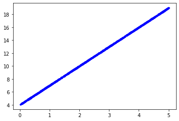

```python
import matplotlib.pyplot as plt

plt.plot(coffee, energy, 'b.')
plt.show()
```

The dataset does indeed have an $x$ range from 0 to the max $x$-value of 5. Notice that the $y$-intercept and slope match our seeded values.

This dataset looks nothing like what we'd see in the real world, though. It would be trivial to fit a line to the data as is; the data is already a straight line. Let's add a little randomness to the data to make it more realistic.

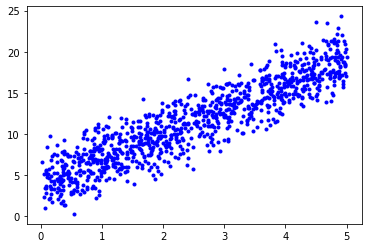

```python
energy = energy + 2 * np.random.randn(DATA_SET_SIZE, 1)

plt.plot(coffee, energy, 'b.')
plt.show()
```

That's much better! There is still a linear trend to the data, but there is much more noise.

# Running the Regression

scikit-learn performs linear regression in its `LinearRegression` module.

```python
from sklearn.linear_model import LinearRegression

lin_reg = LinearRegression()
lin_reg.fit(coffee, energy)
lin_reg.coef_, lin_reg.intercept_
```

```
(array([[3.0263932]]), array([3.90939913]))
```

Not bad! The random noise we added to the data prevented us from exactly predicting the slope and intercept, but our calculations were pretty close.

We can use this slope and intercept to predict new $y$-values given some $x$-values.

```python
coffee_ = np.array([[0.34], [1.65], [2.45], [3.78], [4.56]])

energy_predict = lin_reg.predict(coffee_)
energy_predict
```

```
array([[ 4.93837282],
       [ 8.90294791],
       [11.32406248],
       [15.34916544],
       [17.70975213]])
```

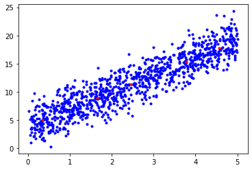

```python
plt.plot(coffee, energy, 'b.')
plt.plot(coffee_, energy_predict, 'r.')
plt.show()
```

And we can use two extreme $x$-values 0 and `X_MAX` to draw the regression line.

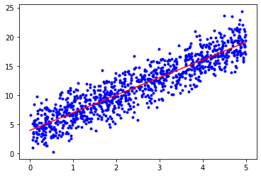

```python
coffee_ = np.array([[0.0], [X_MAX]])
energy_predict = lin_reg.predict(coffee_)

plt.plot(coffee, energy, 'b.')
plt.plot(coffee_, energy_predict, 'r-')
plt.show()
```

# Stochastic Gradient Descent

It is not always practical to run a linear regression using the entire training data set. For cases where training using the entire set is impractical, the stochastic gradient descent method can be used. In scikit-learn this is implemented via the `SGDRegressor`.

```python
from sklearn.linear_model import SGDRegressor

# Create a new Stochastic Gradient Descent regressor.
sgd_reg = SGDRegressor()

# Fit the model.
sgd_reg.fit(coffee, energy.ravel())

# Display the slope and intercept.
sgd_reg.coef_, sgd_reg.intercept_
```

```
(array([3.09924724]), array([3.88926376]))
```

You might notice that the slope and intercept aren't as accurate as what we were getting when processing the entire dataset. This is because the SGDRegressor is only using a subset of the training data.

Let's compare the regression lines calculated by the full linear regressor and the SGD one.

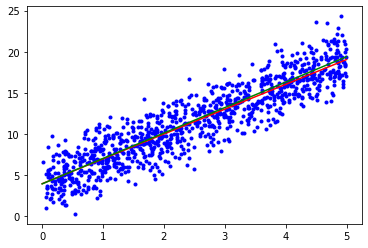

```python
coffee_ = np.array([[0.0], [5.0]])

lin_predict = lin_reg.predict(coffee_)
sgd_predict = sgd_reg.predict(coffee_)

plt.plot(coffee, energy, 'b.')
plt.plot(coffee_, lin_predict, 'r-')
plt.plot(coffee_, sgd_predict, 'g-')
plt.show()
```

It might be hard to see, but the red and green lines are *almost* the same but not quite.

### Challenge: Regressor Parameters

The SGDRegressor has many parameters that can be tuned. Out of the box, our regressor didn't do that well. Let's see if we can tune some of the parameters of the regressor to get its predicted values for the slope and intercept closer to those we predicted using the entire dataset.

Check out the [SGDRegressor documentation](https://scikit-learn.org/stable/modules/generated/sklearn.linear_model.SGDRegressor.html) and look over the parameters available. Pay special attention to parameters related to learning rate and iterations over the data. See if you can tweak the parameters to get within some threshold `EPISLON` of the calculated values below.

```python
import numpy as np
from sklearn.linear_model import SGDRegressor

np.random.seed(21)

# Initialize the dataset attributes.
DATA_SET_SIZE = 1000
X_MAX = 5
INTERCEPT = 4
SLOPE = 3

# Generate the randomized dataset.
coffee = X_MAX * np.random.rand(DATA_SET_SIZE, 1)
energy = SLOPE * coffee + INTERCEPT + 2 * np.random.randn(DATA_SET_SIZE, 1)

sgd_reg = SGDRegressor(
    # TODO(you): Update the parameters to SGDRegressor.
    learning_rate = 'adaptive'
    )

# Fit the model.
sgd_reg.fit(coffee, energy.ravel())

EPSILON = 0.05

print(sgd_reg.coef_, sgd_reg.intercept_)
if abs(SLOPE - sgd_reg.coef_) < EPSILON and abs(INTERCEPT - sgd_reg.intercept_) < EPSILON:
  print("You win!")
else:
  print("Try again :(")
```

```
[2.98928365] [3.99609943]
You win!
```

# Optional: The Normal Equation

If the dataset being processed is small enough, then the slope and $y$-intercept of the regression line can be calculated in-memory exactly. The matrix normal equation can easily be written in NumPy, as seen below.

```python
# x is an Nx1 matrix containing our x-values. The first step in calculating the
# normal equation is to create an Nx2 matrix where each "row" has the value 1
# and the x value.
coffee_ = np.c_[np.ones((DATA_SET_SIZE, 1)), coffee]

norm = np.linalg.inv(coffee_.T.dot(coffee_)).dot(coffee_.T).dot(energy)

calculated_intercept = norm[0][0]
calculated_slope = norm[1][0]

print("Calculated slope {} vs actual {}".format(calculated_slope, SLOPE))
print("Calculated intercept {} vs actual {}".format(calculated_intercept,
                                                    INTERCEPT))
```

```
Calculated slope 2.9912319026307017 vs actual 3
Calculated intercept 3.9871540868029376 vs actual 4
```

We can now use these values to make predictions.

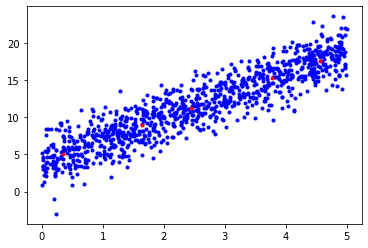

```python
import matplotlib.pyplot as plt
# Create a (5,1) matrix containing values to make predictions on.
coffee_ = np.array([[0.34], [1.65], [2.45], [3.78], [4.56]])

# Convert the matrix to a (5, 2) matrix with ones in the first column
# in order to perform a dot-product against the calculated slope and
# intercept.
coffee_predict = np.c_[np.ones((5, 1)), coffee_]

# Make the predictions.
energy_predict = coffee_predict.dot(norm)

# Plot the original data as blue dots.
plt.plot(coffee, energy, 'b.')

# Plot the predictions as red dots.
plt.plot(coffee_, energy_predict, 'r.')
plt.show()
```

To plot the calculated line as we did for the scikit-learn regression, we can just plug in 0 and 5 (`X_MAX`) to the equation.

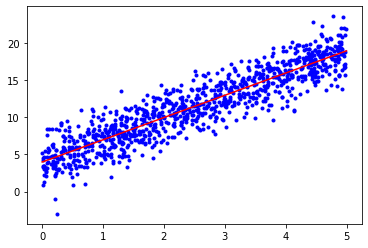

```python
coffee_ = np.array([[0.0], [X_MAX]])
coffee_predict = np.c_[np.ones((2,1)), coffee_]
energy_predict = coffee_predict.dot(norm)

plt.plot(coffee, energy, 'b.')
plt.plot(coffee_, energy_predict, 'r-')
plt.show()
```

# Exercises

For these exercises, we will download a CSV of life expectancies from [GapMinder](https://www.gapminder.org/data/) and create a linear regression predicting life expectancy in the United States.

## Exercise 1: Obtain the Data

Download a CSV of life expectancy data from [GapMinder](https://www.gapminder.org/data/) and read the data into memory using Pandas.

Examine the data using describe.

### Student Solution

```python
# Your code goes here

# Use pandas to get the data and describe it
import pandas as pd

life_expectancy = pd.read_csv("life_expectancy_years.csv")
life_expectancy.describe()
```

|  | 1800 | 1801 | 1802 | 1803 | 1804 | 1805 | 1806 | 1807 | 1808 | 1809 | ... | 2091 | 2092 | 2093 | 2094 | 2095 | 2096 | 2097 | 2098 | 2099 | 2100 |
| --- | --- | --- | --- | --- | --- | --- | --- | --- | --- | --- | --- | --- | --- | --- | --- | --- | --- | --- | --- | --- | --- |
| count | 184.000000 | 184.000000 | 184.000000 | 184.000000 | 184.000000 | 184.000000 | 184.000000 | 184.000000 | 184.000000 | 184.000000 | ... | 184.000000 | 184.00000 | 184.000000 | 184.000000 | 184.000000 | 184.000000 | 184.000000 | 184.000000 | 184.00000 | 184.000000 |
| mean | 31.502717 | 31.461957 | 31.478804 | 31.383152 | 31.459239 | 31.586413 | 31.644565 | 31.598370 | 31.383152 | 31.310326 | ... | 83.758152 | 83.87663 | 83.996196 | 84.119022 | 84.236957 | 84.358152 | 84.478804 | 84.593478 | 84.71087 | 84.829891 |
| std | 3.814689 | 3.806303 | 3.938674 | 3.962376 | 3.934674 | 4.010884 | 4.110598 | 3.981247 | 4.087872 | 4.040580 | ... | 5.600794 | 5.59444 | 5.589074 | 5.577601 | 5.570850 | 5.566060 | 5.556903 | 5.550234 | 5.54055 | 5.532609 |
| min | 23.400000 | 23.400000 | 23.400000 | 19.600000 | 23.400000 | 23.400000 | 23.400000 | 23.400000 | 12.500000 | 13.400000 | ... | 67.100000 | 67.30000 | 67.400000 | 67.500000 | 67.600000 | 67.700000 | 67.800000 | 67.900000 | 68.00000 | 68.100000 |
| 25% | 29.075000 | 28.975000 | 28.900000 | 28.900000 | 28.975000 | 29.075000 | 29.075000 | 29.075000 | 28.975000 | 28.875000 | ... | 79.500000 | 79.70000 | 79.800000 | 79.900000 | 80.075000 | 80.200000 | 80.375000 | 80.475000 | 80.57500 | 80.775000 |
| 50% | 31.750000 | 31.650000 | 31.550000 | 31.500000 | 31.550000 | 31.650000 | 31.750000 | 31.750000 | 31.550000 | 31.500000 | ... | 84.200000 | 84.35000 | 84.450000 | 84.550000 | 84.650000 | 84.750000 | 84.850000 | 85.000000 | 85.15000 | 85.250000 |
| 75% | 33.825000 | 33.900000 | 33.825000 | 33.625000 | 33.725000 | 33.825000 | 33.925000 | 33.925000 | 33.725000 | 33.625000 | ... | 88.125000 | 88.22500 | 88.325000 | 88.500000 | 88.600000 | 88.700000 | 88.800000 | 88.900000 | 89.00000 | 89.100000 |
| max | 42.900000 | 40.300000 | 44.400000 | 44.800000 | 42.800000 | 44.300000 | 45.800000 | 43.600000 | 43.500000 | 41.700000 | ... | 93.700000 | 93.90000 | 94.000000 | 94.100000 | 94.200000 | 94.300000 | 94.400000 | 94.500000 | 94.70000 | 94.800000 |

8 rows × 301 columns

## Exercise 2: Inspect the Data

Examine the data using head and/or tail.

### Student Solution

```python
# Your code goes here
life_expectancy.head()
life_expectancy.tail()
```

|  | country | 1800 | 1801 | 1802 | 1803 | 1804 | 1805 | 1806 | 1807 | 1808 | ... | 2091 | 2092 | 2093 | 2094 | 2095 | 2096 | 2097 | 2098 | 2099 | 2100 |
| --- | --- | --- | --- | --- | --- | --- | --- | --- | --- | --- | --- | --- | --- | --- | --- | --- | --- | --- | --- | --- | --- |
| 182 | Venezuela | 32.2 | 32.2 | 32.2 | 32.2 | 32.2 | 32.2 | 32.2 | 32.2 | 32.2 | ... | 86.2 | 86.3 | 86.5 | 86.6 | 86.7 | 86.9 | 87.0 | 87.1 | 87.2 | 87.3 |
| 183 | Vietnam | 32.0 | 32.0 | 32.0 | 32.0 | 32.0 | 32.0 | 32.0 | 32.0 | 32.0 | ... | 84.3 | 84.4 | 84.5 | 84.6 | 84.7 | 84.8 | 84.9 | 85.0 | 85.2 | 85.3 |
| 184 | Yemen | 23.4 | 23.4 | 23.4 | 23.4 | 23.4 | 23.4 | 23.4 | 23.4 | 23.4 | ... | 77.3 | 77.4 | 77.5 | 77.7 | 77.8 | 77.9 | 78.0 | 78.2 | 78.3 | 78.4 |
| 185 | Zambia | 32.6 | 32.6 | 32.6 | 32.6 | 32.6 | 32.6 | 32.6 | 32.6 | 32.6 | ... | 76.8 | 77.0 | 77.1 | 77.3 | 77.4 | 77.6 | 77.7 | 77.8 | 78.0 | 78.1 |
| 186 | Zimbabwe | 33.7 | 33.7 | 33.7 | 33.7 | 33.7 | 33.7 | 33.7 | 33.7 | 33.7 | ... | 74.5 | 74.6 | 74.7 | 74.8 | 75.0 | 75.1 | 75.3 | 75.4 | 75.5 | 75.7 |

5 rows × 302 columns

## Exercise 3: Preprocess Life Expectancy Column

Extract the life expectancy values for the United States into a NumPy array.

To do this you'll need to find the row that contains data for the United States. When you find that row of data, you'll find the word 'United States' in the first column and then floating point numbers in subsequent columns. The goal of this step is to create a NumPy array containing those numbers, but excluding the first column with the title 'United States'.

### Student Solution

```python
# Your code goes here
import numpy as np

# Get the United States row
us = life_expectancy.loc[life_expectancy['country'] == 'United States']

# Separate the life expectancy values
life = us.values[0][1:]
life
```

```
array([39.4, 39.4, 39.4, 39.4, 39.4, 39.4, 39.4, 39.4, 39.4, 39.4, 39.4,
       39.4, 39.4, 39.4, 39.4, 39.4, 39.4, 39.4, 39.4, 39.4, 39.4, 39.4,
       39.4, 39.4, 39.4, 39.4, 39.4, 39.4, 39.4, 39.4, 39.4, 39.4, 39.4,
       39.4, 39.4, 39.4, 39.4, 39.4, 39.4, 39.4, 39.4, 39.4, 39.4, 39.4,
       39.4, 39.4, 39.4, 39.4, 39.4, 39.4, 39.4, 39.4, 39.4, 39.4, 39.4,
       39.4, 39.4, 39.4, 39.4, 39.4, 39.4, 38.0, 34.5, 34.0, 31.0, 38.0,
       39.4, 39.4, 39.4, 39.4, 39.4, 39.4, 39.4, 39.4, 39.4, 39.4, 39.4,
       39.4, 39.4, 39.4, 39.4, 40.0, 40.6, 41.2, 41.7, 42.3, 42.9, 43.5,
       44.1, 44.6, 45.2, 45.6, 46.0, 46.3, 46.7, 47.1, 47.5, 47.8, 48.2,
       48.6, 49.0, 49.3, 50.5, 50.6, 49.6, 50.3, 50.1, 50.2, 51.9, 52.8,
       51.8, 53.4, 54.1, 53.5, 54.6, 55.1, 54.2, 54.0, 47.2, 55.3, 55.4,
       58.3, 58.1, 57.5, 58.5, 58.5, 58.0, 59.5, 58.4, 58.5, 59.7, 60.4,
       61.1, 61.0, 60.4, 61.0, 60.5, 61.2, 62.5, 63.2, 63.4, 63.9, 64.7,
       64.4, 65.2, 65.7, 66.4, 66.8, 67.4, 67.8, 68.2, 68.3, 68.5, 68.9,
       69.7, 69.7, 69.8, 69.6, 69.8, 70.1, 70.0, 70.4, 70.3, 70.1, 70.4,
       70.5, 70.5, 70.9, 70.5, 70.8, 71.0, 71.3, 71.5, 71.8, 72.2, 72.6,
       73.0, 73.3, 73.6, 73.9, 74.1, 74.4, 74.6, 74.7, 74.8, 74.9, 75.0,
       75.1, 75.2, 75.3, 75.6, 75.7, 75.9, 75.8, 75.8, 75.9, 76.3, 76.6,
       76.8, 76.8, 76.9, 76.9, 77.0, 77.2, 77.5, 77.6, 77.8, 78.0, 78.2,
       78.4, 78.7, 78.8, 78.9, 78.9, 78.9, 78.8, 78.6, 78.6, 78.6, 78.6,
       78.6, 78.7, 78.8, 78.9, 79.0, 79.1, 79.3, 79.5, 79.7, 79.9, 80.1,
       80.3, 80.5, 80.8, 80.9, 81.1, 81.2, 81.4, 81.5, 81.6, 81.8, 81.9,
       82.1, 82.2, 82.3, 82.5, 82.6, 82.8, 82.9, 83.0, 83.2, 83.3, 83.4,
       83.5, 83.7, 83.8, 83.9, 84.0, 84.1, 84.3, 84.4, 84.5, 84.6, 84.7,
       84.8, 84.9, 85.0, 85.2, 85.3, 85.4, 85.5, 85.6, 85.7, 85.8, 85.9,
       86.0, 86.1, 86.2, 86.3, 86.4, 86.5, 86.6, 86.7, 86.8, 86.9, 87.0,
       87.1, 87.2, 87.3, 87.4, 87.5, 87.6, 87.7, 87.8, 87.9, 88.0, 88.1,
       88.2, 88.3, 88.4, 88.5], dtype=object)
```

## Exercise 4: Create Yearly Data

Now we need to create an array of year data from the minimum to the maximum year in the dataset. There are a few ways that this can be done.

The column names (except column 0) are the years. You can extract those years into an array, similarly to what you did for life expectancy. Note that the column names are strings, so you'll want to convert them into integers.

If no years are missing from the dataset, you can also just use a range function to generate numbers between the min and max years.

### Student Solution

```python
# Your code goes here
import numpy as np

# Obtain the columns from us and convert them to type int then to an array
years = us.columns[1:].astype(int).tolist()
years = np.array(years)
years
```

```
array([1800, 1801, 1802, 1803, 1804, 1805, 1806, 1807, 1808, 1809, 1810,
       1811, 1812, 1813, 1814, 1815, 1816, 1817, 1818, 1819, 1820, 1821,
       1822, 1823, 1824, 1825, 1826, 1827, 1828, 1829, 1830, 1831, 1832,
       1833, 1834, 1835, 1836, 1837, 1838, 1839, 1840, 1841, 1842, 1843,
       1844, 1845, 1846, 1847, 1848, 1849, 1850, 1851, 1852, 1853, 1854,
       1855, 1856, 1857, 1858, 1859, 1860, 1861, 1862, 1863, 1864, 1865,
       1866, 1867, 1868, 1869, 1870, 1871, 1872, 1873, 1874, 1875, 1876,
       1877, 1878, 1879, 1880, 1881, 1882, 1883, 1884, 1885, 1886, 1887,
       1888, 1889, 1890, 1891, 1892, 1893, 1894, 1895, 1896, 1897, 1898,
       1899, 1900, 1901, 1902, 1903, 1904, 1905, 1906, 1907, 1908, 1909,
       1910, 1911, 1912, 1913, 1914, 1915, 1916, 1917, 1918, 1919, 1920,
       1921, 1922, 1923, 1924, 1925, 1926, 1927, 1928, 1929, 1930, 1931,
       1932, 1933, 1934, 1935, 1936, 1937, 1938, 1939, 1940, 1941, 1942,
       1943, 1944, 1945, 1946, 1947, 1948, 1949, 1950, 1951, 1952, 1953,
       1954, 1955, 1956, 1957, 1958, 1959, 1960, 1961, 1962, 1963, 1964,
       1965, 1966, 1967, 1968, 1969, 1970, 1971, 1972, 1973, 1974, 1975,
       1976, 1977, 1978, 1979, 1980, 1981, 1982, 1983, 1984, 1985, 1986,
       1987, 1988, 1989, 1990, 1991, 1992, 1993, 1994, 1995, 1996, 1997,
       1998, 1999, 2000, 2001, 2002, 2003, 2004, 2005, 2006, 2007, 2008,
       2009, 2010, 2011, 2012, 2013, 2014, 2015, 2016, 2017, 2018, 2019,
       2020, 2021, 2022, 2023, 2024, 2025, 2026, 2027, 2028, 2029, 2030,
       2031, 2032, 2033, 2034, 2035, 2036, 2037, 2038, 2039, 2040, 2041,
       2042, 2043, 2044, 2045, 2046, 2047, 2048, 2049, 2050, 2051, 2052,
       2053, 2054, 2055, 2056, 2057, 2058, 2059, 2060, 2061, 2062, 2063,
       2064, 2065, 2066, 2067, 2068, 2069, 2070, 2071, 2072, 2073, 2074,
       2075, 2076, 2077, 2078, 2079, 2080, 2081, 2082, 2083, 2084, 2085,
       2086, 2087, 2088, 2089, 2090, 2091, 2092, 2093, 2094, 2095, 2096,
       2097, 2098, 2099, 2100])
```

## Exercise 5: Plot the Data

Create a scatterplot of the data.

### Student Solution

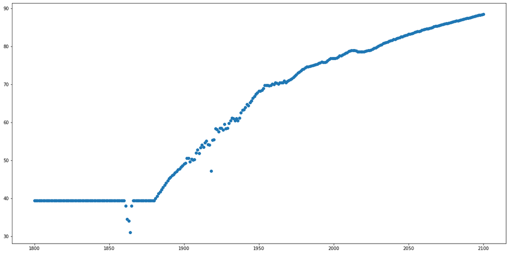

```python
# Your code goes here
import matplotlib.pyplot as plt

plt.figure(figsize=(20,10))
plt.scatter(years, life)
plt.show()
```

## Exercise 6: Subset the Data

Split off 20% of the data as a test set, and keep the rest for training.

To do this it will be useful to create a `DataFrame` and store the years and life expectancy arrays created above as columns in that dataframe.

You can then randomize and split the dataframe, or use scikit-learn's built in test/train data splitter.

### Student Solution

```python
# Your code goes here
from sklearn.model_selection import train_test_split

# Use train_test_split with test_size = 0.2
years_train, years_test, life_train, life_test = train_test_split(years, life, test_size = 0.2)
years_train, years_test, life_train, life_test
```

```
(array([1887, 2039, 2063, 2065, 1885, 2025, 2047, 1999, 2001, 1942, 1962,
        1845, 2085, 2015, 1846, 1849, 1917, 1964, 2078, 2006, 1930, 2003,
        1871, 1941, 2051, 1995, 1929, 1927, 1858, 1905, 1966, 1805, 1834,
        1982, 2040, 1811, 1972, 2069, 1949, 1832, 1990, 1856, 1883, 1895,
        1808, 2086, 1908, 1931, 2036, 1874, 2093, 1977, 1833, 1984, 1989,
        2024, 1823, 1827, 1854, 2043, 2029, 1980, 1903, 1920, 1974, 1946,
        2083, 1836, 1948, 1882, 1965, 1936, 1873, 1860, 1967, 1851, 2014,
        1958, 1900, 1963, 1886, 1954, 1877, 2030, 1841, 1956, 1985, 1925,
        1961, 1957, 2011, 2013, 1853, 1838, 1862, 1879, 1913, 2100, 2089,
        1906, 1839, 1901, 1801, 2028, 1912, 1890, 1850, 1943, 1820, 1975,
        2070, 2000, 1973, 1992, 1938, 2075, 2064, 1855, 2062, 1893, 1881,
        1924, 1918, 2068, 2077, 2067, 1876, 1996, 1812, 2091, 1969, 1896,
        1825, 2084, 1802, 1921, 1914, 1831, 1991, 1934, 1951, 2022, 1861,
        2057, 1821, 1904, 1899, 2017, 2018, 1865, 2026, 1809, 1804, 1926,
        2094, 2082, 2056, 1923, 1868, 2016, 1817, 2098, 1959, 2074, 2032,
        2095, 2020, 1909, 1824, 1816, 2060, 2076, 2007, 2061, 1864, 1976,
        2021, 2044, 1940, 1830, 1928, 2058, 2031, 1978, 1829, 2008, 2055,
        2035, 1953, 1911, 1915, 1867, 2045, 1848, 1847, 1822, 1981, 1872,
        2034, 1857, 1955, 2081, 1814, 1922, 2042, 1950, 1889, 1880, 1840,
        1815, 2090, 1910, 1863, 1939, 2059, 2038, 1800, 2046, 1828, 1952,
        1998, 1932, 2092, 1979, 1894, 1859, 2079, 2072, 1843, 1892, 1960,
        2071, 1935, 1987, 1888, 1810, 2037, 2099, 1971, 1944]),
 array([2004, 2052, 2010, 1826, 1933, 1997, 1884, 1988, 1968, 2023, 2012,
        1994, 1806, 2019, 1902, 1907, 2096, 2097, 1983, 1870, 1813, 1986,
        1869, 2002, 1852, 2009, 2087, 1945, 1819, 2050, 1916, 1898, 1837,
        2048, 1919, 1875, 1818, 2054, 1897, 2005, 1803, 2073, 1947, 2066,
        1937, 2053, 1891, 2080, 2088, 1842, 1878, 1993, 2041, 2049, 2027,
        1866, 1835, 1970, 1844, 1807, 2033]),
 array([43.5, 81.6, 84.7, 84.9, 42.3, 79.1, 82.8, 76.8, 76.9, 64.7, 70.3,
        39.4, 87.0, 78.8, 39.4, 39.4, 54.0, 70.4, 86.3, 77.8, 59.7, 77.2,
        39.4, 63.9, 83.3, 75.9, 58.5, 59.5, 39.4, 50.3, 70.5, 39.4, 39.4,
        74.6, 81.8, 39.4, 71.5, 85.4, 67.8, 39.4, 75.6, 39.4, 41.2, 47.1,
        39.4, 87.1, 51.9, 60.4, 81.2, 39.4, 87.8, 73.3, 39.4, 74.8, 75.3,
        79.0, 39.4, 39.4, 39.4, 82.2, 79.9, 74.1, 50.6, 55.4, 72.2, 66.4,
        86.8, 39.4, 67.4, 40.6, 70.5, 60.5, 39.4, 39.4, 70.9, 39.4, 78.9,
        69.8, 49.0, 70.1, 42.9, 69.7, 39.4, 80.1, 39.4, 69.8, 74.9, 58.5,
        70.4, 69.6, 78.8, 78.9, 39.4, 39.4, 34.5, 39.4, 53.5, 88.5, 87.4,
        50.1, 39.4, 49.3, 39.4, 79.7, 54.1, 45.2, 39.4, 64.4, 39.4, 72.6,
        85.5, 76.9, 71.8, 75.9, 62.5, 86.0, 84.8, 39.4, 84.6, 46.3, 40.0,
        58.5, 47.2, 85.3, 86.2, 85.2, 39.4, 76.3, 39.4, 87.6, 70.8, 47.5,
        39.4, 86.9, 39.4, 58.3, 54.6, 39.4, 75.7, 60.4, 68.3, 78.8, 38.0,
        84.0, 39.4, 49.6, 48.6, 78.6, 78.6, 38.0, 79.3, 39.4, 39.4, 58.0,
        87.9, 86.7, 83.9, 57.5, 39.4, 78.6, 39.4, 88.3, 70.1, 85.9, 80.5,
        88.0, 78.6, 52.8, 39.4, 39.4, 84.4, 86.1, 78.0, 84.5, 31.0, 73.0,
        78.7, 82.3, 63.4, 39.4, 58.4, 84.1, 80.3, 73.6, 39.4, 78.2, 83.8,
        81.1, 68.9, 53.4, 55.1, 39.4, 82.5, 39.4, 39.4, 39.4, 74.4, 39.4,
        80.9, 39.4, 69.7, 86.6, 39.4, 58.1, 82.1, 68.2, 44.6, 39.4, 39.4,
        39.4, 87.5, 51.8, 34.0, 63.2, 84.3, 81.5, 39.4, 82.6, 39.4, 68.5,
        76.8, 61.1, 87.7, 73.9, 46.7, 39.4, 86.4, 85.7, 39.4, 46.0, 70.0,
        85.6, 61.0, 75.1, 44.1, 39.4, 81.4, 88.4, 71.3, 65.2], dtype=object),
 array([77.5, 83.4, 78.7, 39.4, 61.0, 76.6, 41.7, 75.2, 70.5, 78.9, 78.9,
        75.8, 39.4, 78.6, 50.5, 50.2, 88.1, 88.2, 74.7, 39.4, 39.4, 75.0,
        39.4, 77.0, 39.4, 78.4, 87.2, 65.7, 39.4, 83.2, 54.2, 48.2, 39.4,
        82.9, 55.3, 39.4, 39.4, 83.7, 47.8, 77.6, 39.4, 85.8, 66.8, 85.0,
        61.2, 83.5, 45.6, 86.5, 87.3, 39.4, 39.4, 75.8, 81.9, 83.0, 79.5,
        39.4, 39.4, 71.0, 39.4, 39.4, 80.8], dtype=object))
```

## Exercise 7: Train a Model

Use `LinearRegression` in scikit-learn to create a model.

### Student Solution

```python
# Your code goes here
from sklearn.linear_model import LinearRegression
import matplotlib.pyplot as plt

# Create Linear Regression
years = years.reshape(-1,1)
regression = LinearRegression()
regression.fit(years, life)
```

```
LinearRegression()
```

## Exercise 8: Test Your Model

Use the test data you put aside to make predictions of life expectancy based on year. Compare the predictions to the actual data by using scikit-learn to calculate the root mean squared error.

### Student Solution

```python
# Your code goes here
from sklearn.metrics import mean_squared_error

years_test = years_test.reshape(-1,1)

# Predict based on year
life_predict = regression.predict(years_test)
life_predict

# Calculate mean squared error
mean_squared_error(life_test, life_predict, squared='False')
```

```
15.778720465424575
```

## Exercise 9: Plot Your Regression

Create a scatter plot of the full set of life expectancy data. Draw your regression line over the scatterplot.

### Student Solution

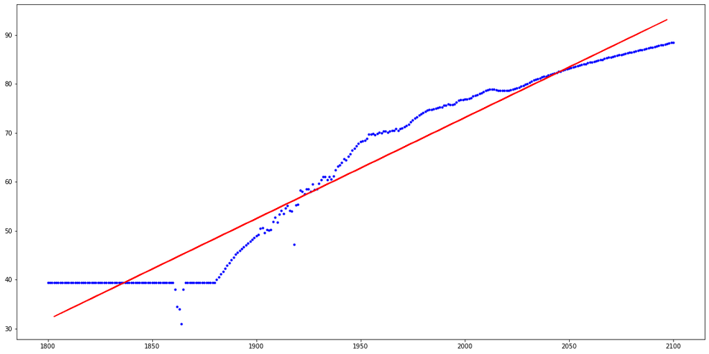

```python
# Your code goes here
import matplotlib.pyplot as plt

# Scatter plot
plt.figure(figsize=(20,10))
plt.plot(years, life, 'b.')

# Regression line
plt.plot(years_test, life_predict, 'r-')
plt.show()
```